# Assignment3

Jiayuan Zhang

April 14, 2019

## Homework 3

## Investigate the data with Plots

## Section 1 - Overall exploration

This is a report of investigating federal R and D spending, climate spending, and energy spending data.

I first plotted the data of the gcc spending of different departments in different year.This plot shows that gcc_spending varies a lot across the departments. The most obvisou thing is that NASA is the department with the largest gcc_spending.Overall, the plot shows an increased trend of the gcc_spending across the years.

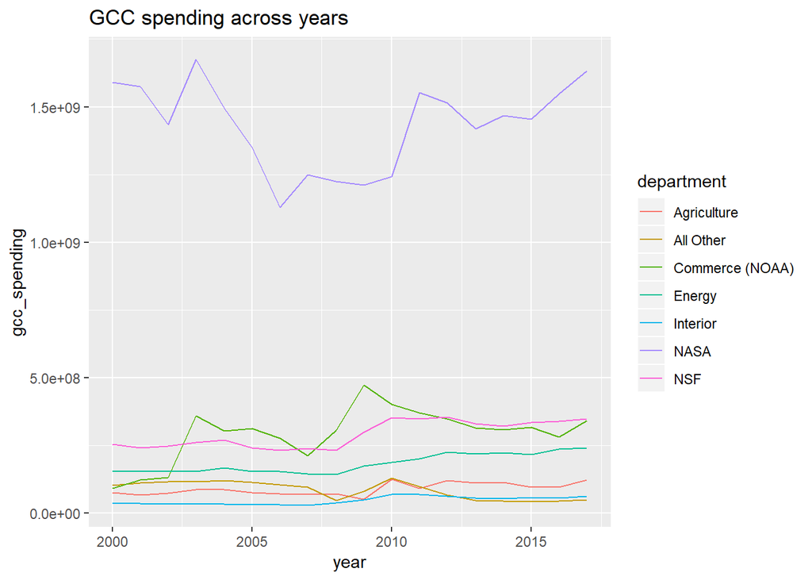

In the next plot, I plot the energy spending of departments across the years. In this plot, we can see that the two departments that have the highest energy_spending are Atomic Energy Defense and Office of Science R&D. The plot also shows an increased trend of enegery_spending across the years.

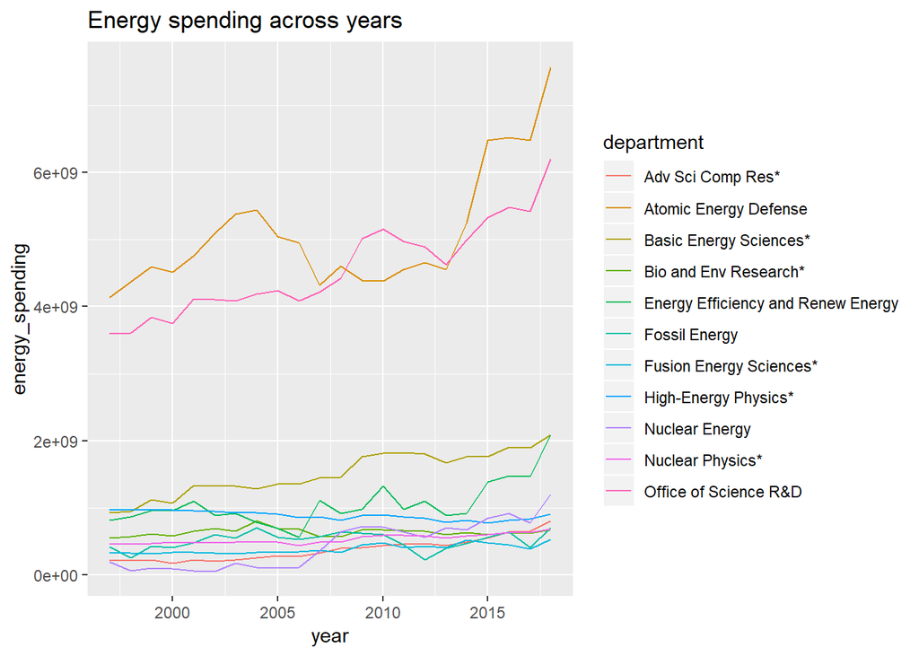

The next plots show the data of the fed of departments across the years. Becasue except the research and development data,in which different departments have different budget across the year. The plot shows the budgets of departments across the years. However, in the data of Total Federal Government spending in inflation-adjusted (constant) dollars, we find that departments share the same value per year. This is the same to the data of Total Discretionary Federal Government spending in inflation-adjusted (constant) dollars and GDP. It is the reason why the last three plots only have one line.

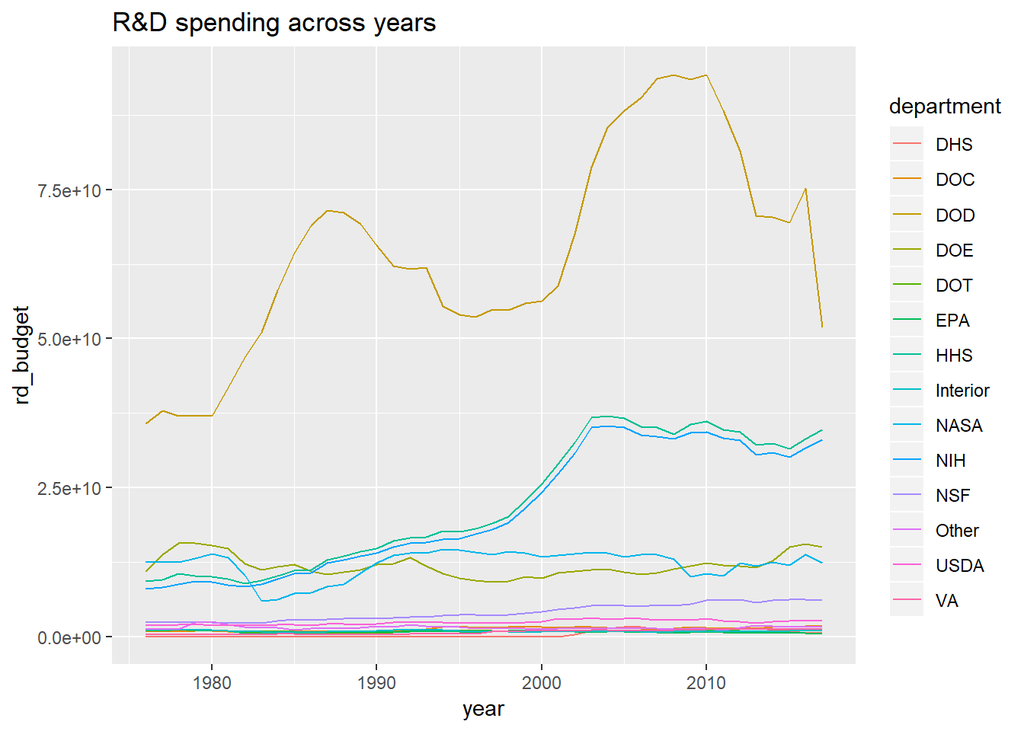

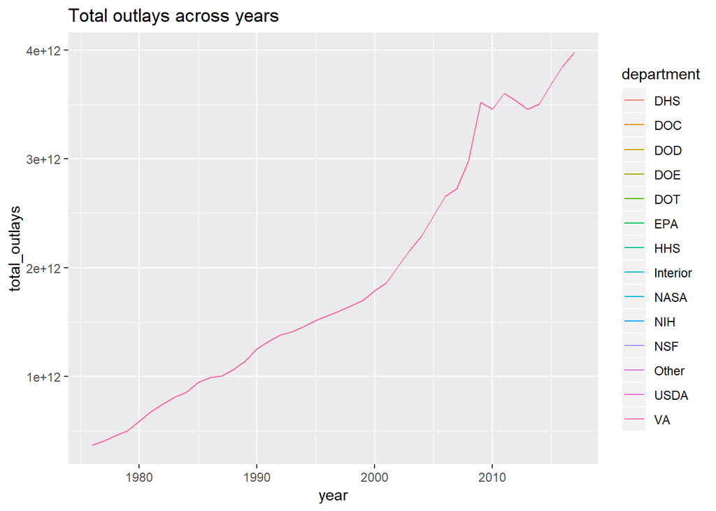

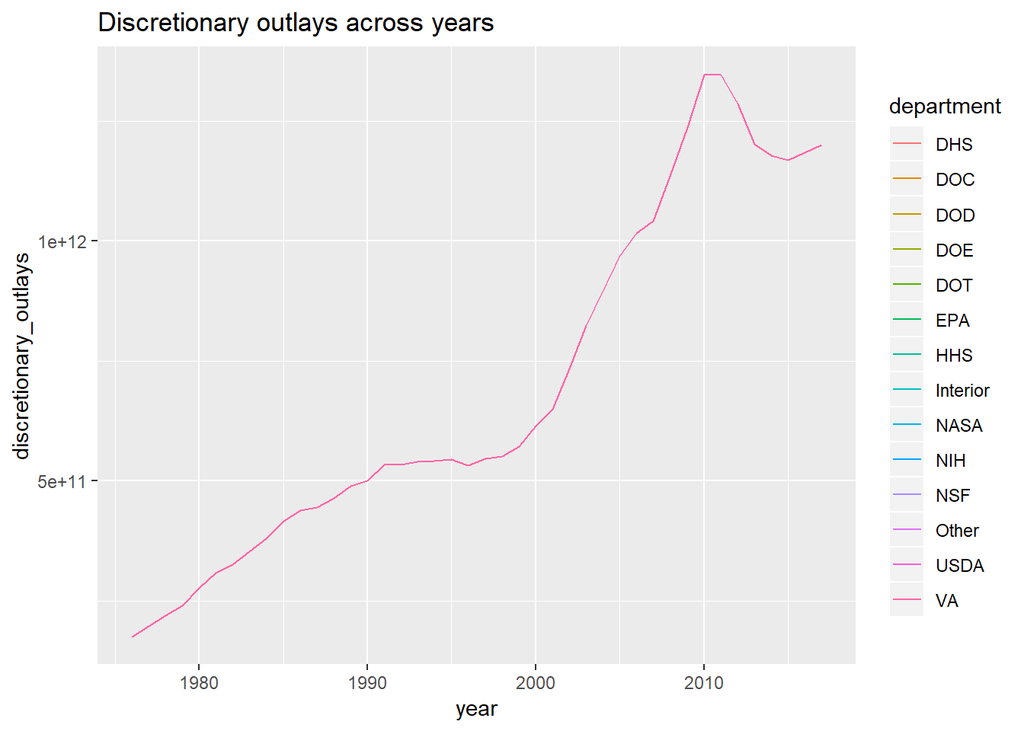

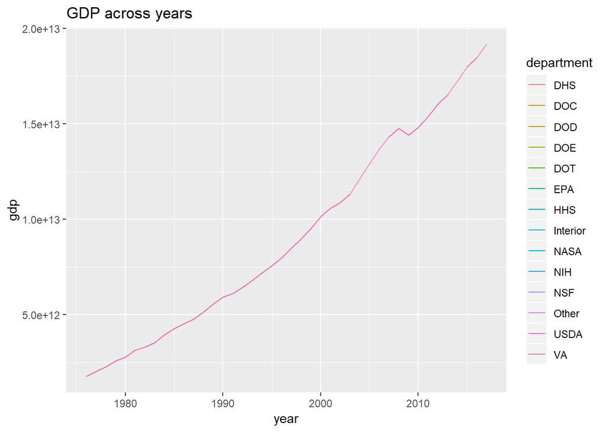

## Section 2 - Relationship between the gcc_spending and energy_spending

In the next step, we are going to investigate the relationship between the gcc_spending and energy_spending. The data is generated from different department. Therefore we cannot combine these two data sets with department. Instead, we combine them with year. We want to investigate whether gcc_spending and energy_spending are related across the year. The plot below shows the relationship.

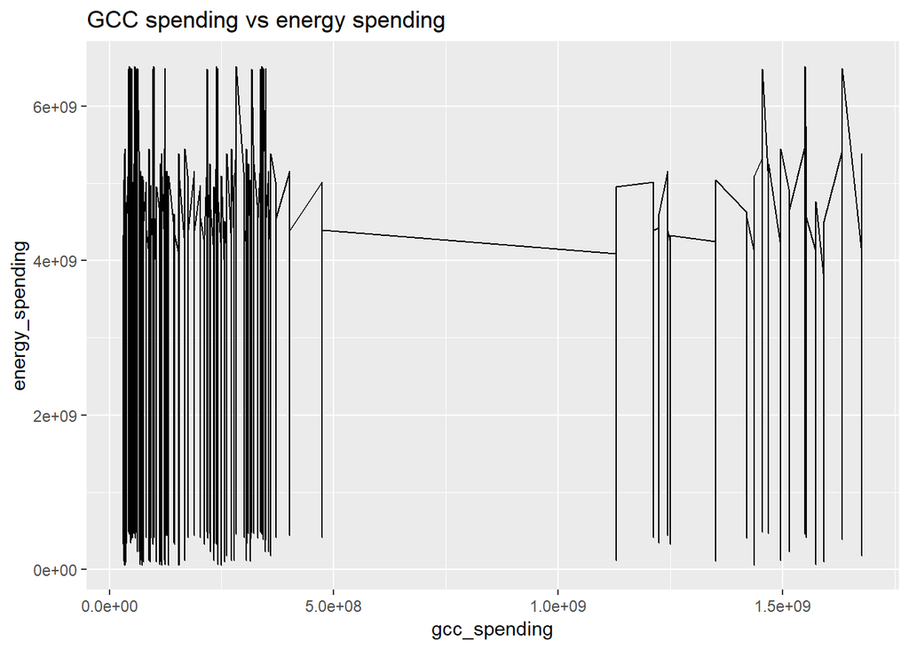

```
##
## Call:
## lm(formula = Department_C_E_F$gcc_spending ~ Department_C_E_F$energy_spending)
##
## Residuals:
##        Min         1Q     Median         3Q        Max
## -319049170 -269938394 -190299868  -23174378 1331290859
##
## Coefficients:
##                                   Estimate Std. Error t value Pr(>|t|)
## (Intercept)                      3.446e+08  4.388e+06  78.533   <2e-16 ***
## Department_C_E_F$energy_spending 1.296e-03  1.982e-03   0.654    0.513
## ---
## Signif. codes:  0 '***' 0.001 '**' 0.01 '*' 0.05 '.' 0.1 ' ' 1
##
## Residual standard error: 458500000 on 19402 degrees of freedom
## Multiple R-squared:  2.203e-05,  Adjusted R-squared:  -2.951e-05
## F-statistic: 0.4274 on 1 and 19402 DF,  p-value: 0.5133
```

We can see from the plot that the data does not show a specific relationship between the two variables. We aslo run a regression with these two variables and the below are the regression results. The r-square is 2.202563910^{-5}, which is pretty low. The p-value is 0.5132995, which does not indicate any relationship between the variables. It makes sense because the gcc_spedning and energy_spending data come from different departments. We only combine them by year.

## Section 3 - Relationship between rd_budget and gcc_spending

Since we cannot find the relationship between the energy_spedning and gcc_spending with different departments across the year. In the next step, we will work on the data set with same departments across the year. We combine the federal R&D data with climate data by deparment and year. The plot below shows the relationship between rd_budget and gcc_spending for three departments - NASA,NSF,and Interior.The plot shows that as the rd_budget increases, the gcc_spending also increases.

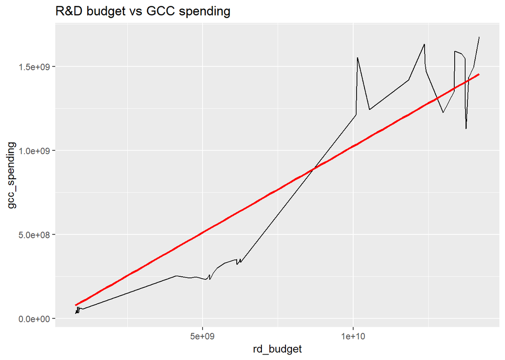

We take a closer look at the relationship by seperating the years.

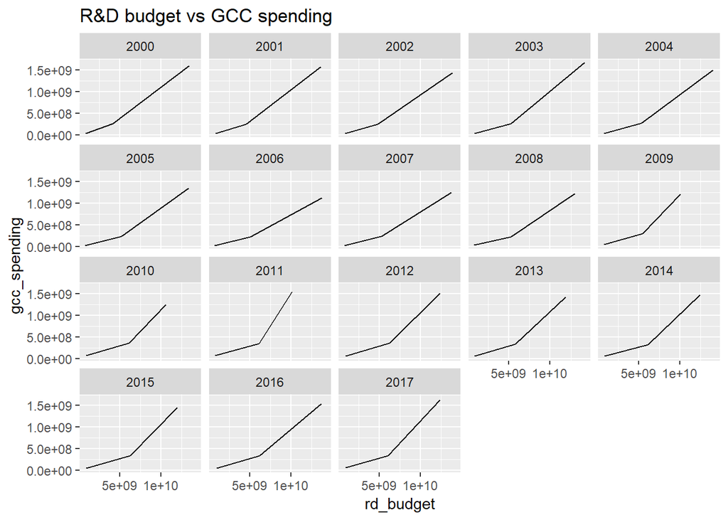

```
##
## Call:
## lm(formula = FEC$rd_budget ~ FEC$gcc_spending)
##
## Residuals:
##        Min         1Q     Median         3Q        Max
## -3.621e+09 -1.258e+09 -6.111e+08  1.488e+09  3.251e+09
##
## Coefficients:
##                   Estimate Std. Error t value Pr(>|t|)
## (Intercept)      1.793e+09  2.835e+08   6.323 5.93e-08 ***
## FEC$gcc_spending 7.715e+00  3.338e-01  23.111  < 2e-16 ***
## ---
## Signif. codes:  0 '***' 0.001 '**' 0.01 '*' 0.05 '.' 0.1 ' ' 1
##
## Residual standard error: 1.498e+09 on 52 degrees of freedom
## Multiple R-squared:  0.9113, Adjusted R-squared:  0.9096
## F-statistic: 534.1 on 1 and 52 DF,  p-value: < 2.2e-16
```

The plots show the relationship between rd_budget and gcc_spending in different years. They show that these two variables are positive related even in different years. We then run a regression between these two variables. The regression summary is provided above and the r-square is 0.9112804 and p-value is 5.125756210^{-29}. The r-square is 0.9112804, which is pretty high, and the p-value 5.125756210^{-29} also indicates that the relationship is significant. The coefficient is 7.7153832, whose magnitude is positive. In this section, we conclude that rd_budget is positively related with gcc_spending.

## Section 4 What drive GDP?

```
##
## Call:
## lm(formula = FEC$gdp ~ FEC$rd_budget + FEC$total_outlays + FEC$discretionary_outlays)
##
## Residuals:
##        Min         1Q     Median         3Q        Max
## -1.918e+12 -4.221e+11  1.286e+11  5.533e+11  1.097e+12
##
## Coefficients:
##                             Estimate Std. Error t value Pr(>|t|)
## (Intercept)                4.839e+12  4.863e+11   9.951 1.89e-13 ***
## FEC$rd_budget              6.948e+00  1.945e+01   0.357    0.722
## FEC$total_outlays          5.315e+00  3.649e-01  14.565  < 2e-16 ***
## FEC$discretionary_outlays -5.877e+00  1.164e+00  -5.050 6.24e-06 ***
## ---
## Signif. codes:  0 '***' 0.001 '**' 0.01 '*' 0.05 '.' 0.1 ' ' 1
##
## Residual standard error: 7.05e+11 on 50 degrees of freedom
## Multiple R-squared:  0.9369, Adjusted R-squared:  0.9331
## F-statistic: 247.6 on 3 and 50 DF,  p-value: < 2.2e-16
```